# HHL Algorithm Implementation in Qiskit - Uncomputation (Inverse QPE)

Python

Quantum Computing

A step-by-step implementation of the uncomputation stage of the HHL algorithm using Qiskit.

Author

Qingsen Zhang

Published

January 30, 2025

# HHL Algorithm Implementation in Qiskit

## Introduction

This document provides a step-by-step implementation of the HHL algorithm using Qiskit. The algorithm is broken into four key phases:

1. **State Preparation**
2. **Quantum Phase Estimation (QPE)**
3. **Controlled Rotation & Measurement of the Ancilla Qubit**
4. ***Uncomputation (Inverse QPE)**

### Numerical Example

$A=\begin{bmatrix}1 & -\frac{1}{3}\\-\frac{1}{3} & 1\end{bmatrix}$  
$\vec{b}=\begin{bmatrix}0\\1\end{bmatrix}$

### Variables

$n_b$: # of qubits in `b-register`

$N_b=2^{n_b}$: # of unknows (length of $\vec{b}$, $len(\vec{b})=len(\vec{x})$)

$n_c$: # of qubits in `c-register`

a larger $n_c$ results in higher accuracy when the encoding is not exact

$N=2^n$

$t=\frac{\pi}{8}$: time variable, should be multiple of $2\pi$

$C=0.01$: a constant to pick, try to make $C$ as large as possible while $-1\leq\frac{C}{\tilde{\lambda_j}} \leq 1$

```python
N_b = 2 # number of variables (b.shape[0])
n_b = int(np.log2(N_b)) # number of qubits in b-register
# n_b = 1 # N_b = 2^(n_b), n_b = np.log2(N_b)
n_c = 1 # number of qubits in c-register
N_c = 2 # N_c = 2^(n_c)
t = np.pi/8
C = 0.01
```

## Phase 4: Uncomputation (Inverse QPE)

The goal for this phase is to remove unnecessary entanglements such that ensures correct final measurement. After uncomputing, the quantum state should ideally be close to $|x\rangle$, where $|x\rangle = A^{-1}|b\rangle$.

After Uncomputation, we will finally get $\psi_{final}=|x\rangle\otimes|0\rangle_c\otimes|0\rangle_a$

```python
# prepare the previous steps
mat_A = np.array([[1, -1/3], [-1/3, 1]])
vec_b = np.array([0,1])
psi_1, qr_b, qr_c, qr_a = state_prep(mat_A, vec_b, n_c=1)
psi_4 = phase_estimation(psi_1, qr_b, qr_c, mat_A, t)
psi_6 = controlled_rotation(psi_4, qr_c, qr_a, C=C, t=t, n_c=n_c)

# psi_6.draw(output='mpl')
```

### Step 1. Apply QFT on `c-register`

Apply QFT on `c-register` to move the phase-encoded eigenvalue information into a superposition of computational basis states.

Given $|\psi_6\rangle=\frac{1}{\sqrt{\sum\limits^{2^{n_b}-1}_{j=0}|\frac{b_jC}{\tilde{\lambda_j}}|^2}}\sum\limits^{2^{n_b}-1}_{j=0}b_j|u_j\rangle|\tilde{\lambda_j}\rangle\frac{C}{\tilde{\lambda_j}}|1\rangle_a$
$$\begin{align}
|\psi_7\rangle &= \frac{1}{\sqrt{\sum\limits^{2^{n_b}-1}*{j=0}|\frac{b_jC}{\tilde{\lambda_j}}|^2}}\sum\limits^{2^{n_b}-1}_{j=0}\frac{b_jC}{\tilde{\lambda_j}}|u_j\rangle\text{QFT}|\tilde{\lambda_j}\rangle|1\rangle_a\\&=\frac{1}{\sqrt{\sum\limits^{2^{n_b}-1}*{j=0}|\frac{b_jC}{\tilde{\lambda_j}}|^2}}\sum\limits^{2^{n_b}-1}_{j=0}\frac{b_jC}{\tilde{\lambda_j}}|u_j\rangle~~~(\frac{1}{2^{\frac{2}{n}}}\sum\limits^{2^n-1}_{y=0}e^{2\pi i y\tilde{\lambda_j}/N}|y\rangle)~~~|1\rangle_a
\end{align}$$

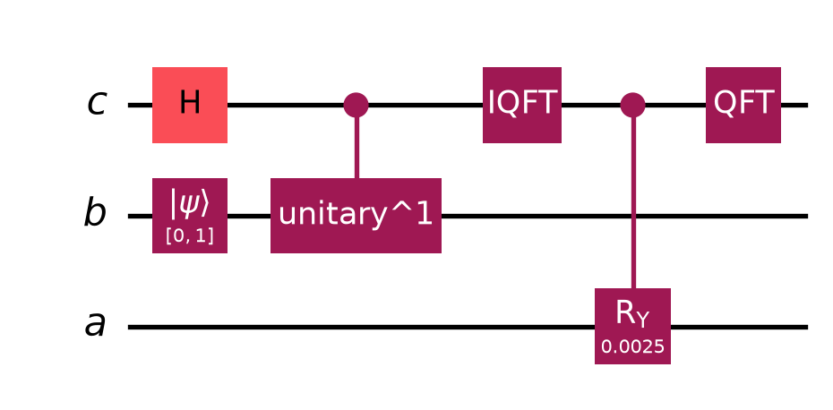

```python
psi_7 = psi_6.copy()
psi_7.append(QFT(n_c, do_swaps=False), qr_c)

psi_7.draw(output='mpl')
```

### Step 2. Inverse Controlled-Rotations on `b-register`.

Then inverse controlled-rotations of the `b-register` by the clock qubits are applied with $U^{−1} = e^{−iAt}$.

Similar to the forward process, when the controlling r-th clock qubit is $|0\rangle$, $|u_j\rangle$ will not be affected. If the r-th clock qubit is $|1\rangle$, $(U^{−1})^{2r}$ will be applied to $|u_j\rangle$. This is equivalent to multiplying $e^{−i\lambda_jty}$ if the c-register is $|y\rangle$ since $2\pi i \phi=i\lambda_jt$

$$|\psi_8\rangle=\frac{1}{2^{\frac{n}{2}}\sqrt{\sum\limits^{2^{n_b}-1}_{j=0}|\frac{b_jC}{\tilde{\lambda_j}}|^2}}\sum\limits^{2^{n_b}-1}_{j=0}\frac{b_jC}{\tilde{\lambda_j}}|u_j\rangle~~~\left(\sum\limits^{2^n-1}_{y=0}e^{-i\lambda_jty}e^{2\pi i y\tilde{\lambda_j}/N}|y\rangle\right)~~~|1\rangle_a$$

Since we choose $\tilde{\lambda_j}=\frac{N\lambda_jt}{2\pi}$, the two exponential terms cancel each other
$$\begin{align}
|\psi_8\rangle &=\frac{1}{2^{\frac{n}{2}}\sqrt{\sum\limits^{2^{n_b}-1}_{j=0}|\frac{b_jC}{\tilde{\lambda_j}}|^2}}\sum\limits^{2^{n_b}-1}_{j=0}\frac{b_jC}{\tilde{\lambda_j}}|u_j\rangle~~~\sum\limits^{2^n-1}_{y=0}|y\rangle)~~~|1\rangle_a\\
&=\frac{C}{2^{\frac{n}{2}}\sqrt{\sum\limits^{2^{n_b}-1}_{j=0}|\frac{b_jC}{\tilde{\lambda_j}}|^2}}|x\rangle\sum\limits^{2^n-1}_{y=0}|y\rangle|1\rangle_a
\end{align}$$

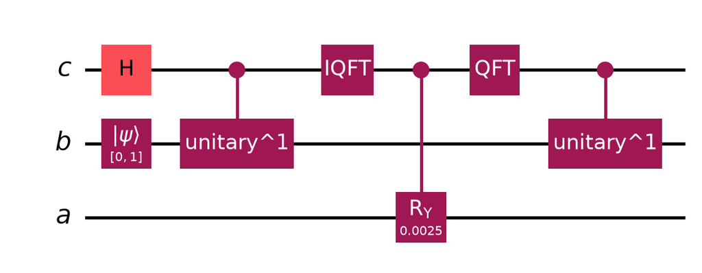

```python
psi_8=psi_7.copy()
U_inv = expm(-1j * t * mat_A)
U_gate_inv = UnitaryGate(U_inv, label="e^{-iAt}")  # Inverse U gate


# Apply inverse controlled-U operations in reverse order
for j in reversed(range(n_c)):
    power = 2**j
    controlled_U_pow_inv = U_gate_inv.power(power).control(1)
    psi_8.append(controlled_U_pow_inv, [qr_c[j], *qr_b])

psi_8.draw(output='mpl')
```

### Step 3 Apply Hadamard Gate

The clock qubits and the b-register are now *unentangled* and the `b-register` stores $|x\rangle$. Next, we can apply the Hadamard Gate on the clock qubits such that we get:

$$\begin{align}
|\psi_9\rangle &= \frac{1}{\sqrt{\sum\limits^{2^{n_b}-1}_{j=0}|\frac{b_jC}{\tilde{\lambda_j}}|^2}}|x\rangle\sum\limits^{2^{n_b}-1}_{j=0}\frac{b_jC}{\lambda_j}|u_j\rangle^{\otimes n}_c|1\rangle_a\\
&=|x\rangle_b|0\rangle_c^{\otimes n}|1\rangle_a
\end{align}$$

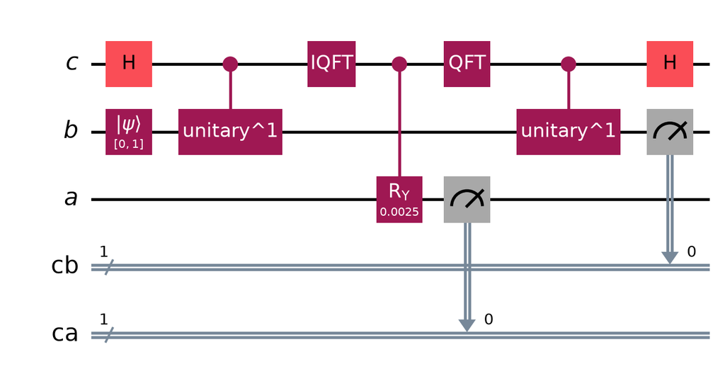

```python
psi_9 = psi_8.copy()
psi_9.h(qr_c)
psi_9.draw(output='mpl')
# Do the measurement
c_b = ClassicalRegister(len(qr_b), name='cb')  # 存储 b-register 测量值
c_a = ClassicalRegister(1, name='ca')  # 存储 a-register 测量值
psi_9.add_register(c_b, c_a)  # 添加经典寄存器

psi_9.measure(qr_b, c_b)  # 测量 b-register 并存入 cb
psi_9.measure(qr_a, c_a)  # 测量 a-register 并存入 ca

psi_9.draw(output='mpl')
```

```python
# 运行并查看结果
simulator = Aer.get_backend('statevector_simulator')
t_psi_9 = transpile(psi_9, simulator)
result = simulator.run(t_psi_9, shots=2 ** 10).result()
counts = result.get_counts(t_psi_9)
print(counts)

# 解析测量结果
measured_a1 = sum(counts[key] for key in counts if key[-1] == '1')
measured_a0 = sum(counts[key] for key in counts if key[-1] == '0')

# 计算归一化比值
if measured_a1 + measured_a0 > 0:
    print("P(a=1) =", measured_a1 / (measured_a1 + measured_a0))
    print("P(a=0) =", measured_a0 / (measured_a1 + measured_a0))

filtered_counts = {key[:-1]: count for key, count in counts.items() if key[-1] == '1'}
total = sum(filtered_counts.values())
if total > 0:
    print("b-register state after post-select:")
    for state, count in filtered_counts.items():
        print(f"|{state}⟩: {count/total:.4f}")
```

```
{'0 1': 1024}
P(a=1) = 1.0
P(a=0) = 0.0
b-register state after post-select:
|0 ⟩: 1.0000
```

### All in one function

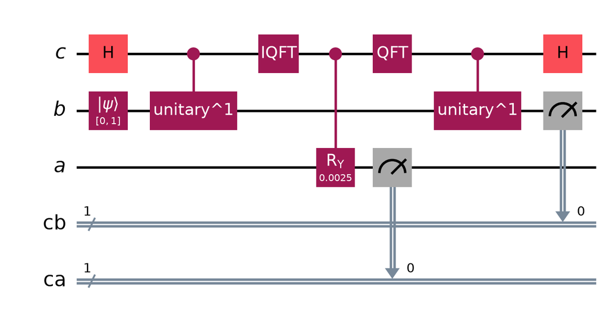

```python
def uncomputation(qc, qr_b, qr_c, qr_a, mat_A, t, n_c):
    """
    Complete uncomputation phase (Phase 4) of HHL algorithm
    """
    # Step 1: Apply QFT on c-register
    qc.append(QFT(n_c, do_swaps=False), qr_c)

    # Step 2: Inverse controlled-U operations
    U_inv = expm(-1j * t * mat_A)
    U_gate_inv = UnitaryGate(U_inv, label="e^{-iAt}")

    for j in reversed(range(n_c)):
        power = 2**j
        controlled_U_pow_inv = U_gate_inv.power(power).control(1)
        qc.append(controlled_U_pow_inv, [qr_c[j], *qr_b])

    # Step 3: Apply Hadamard on c-register
    qc.h(qr_c)

    return qc

# Test the uncomputation function
mat_A = np.array([[1, -1/3], [-1/3, 1]])
vec_b = np.array([0,1])
t = np.pi/8
C = 0.01

psi_1, qr_b, qr_c, qr_a = state_prep(mat_A, vec_b, n_c=1)
psi_4 = phase_estimation(psi_1, qr_b, qr_c, mat_A, t)
psi_6 = controlled_rotation(psi_4, qr_c, qr_a, C=C, t=t, n_c=n_c)
psi_9 = uncomputation(psi_6, qr_b, qr_c, qr_a, mat_A, t, n_c=1)

# Add measurement registers
c_b = ClassicalRegister(len(qr_b), name='cb')
c_a = ClassicalRegister(1, name='ca')
psi_9.add_register(c_b, c_a)
psi_9.measure(qr_b, c_b)
psi_9.measure(qr_a, c_a)

psi_9.draw(output='mpl')
```

prev Controlled Rotation  
next is HHL Complete Version